# Regression Analysis

2. Preliminary Knowledge | Special Lecture for KINS

Boncho Ku, Ph.D. in Statistics

secondmoon@kiom.re.kr

Digital Health Research Division

Korea Institute of Oriental Medicine

2026-09-01

# Preliminary Knowledge

## 행렬 표기의 필요성

### 질문

- 회귀 = 조건부 기댓값 $E(Y \mid X = x)$
- **질문**: 조건부 기댓값을 계산하기 위해 필요한 수학적, 통계학적 도구는?

관측 하나마다 회귀식을 정의하려면 동일한 형태의 식이 $n$개 필요

$$\begin{aligned}
y_1 &= \beta_0+\beta_1 x_{11}+\cdots+\varepsilon_1\\
y_2 &= \beta_0+\beta_1 x_{21}+\cdots+\varepsilon_2\\
&\;\;\vdots\\
y_{30} &= \beta_0+\beta_1 x_{30,1}+\cdots+\varepsilon_{n}
\end{aligned}$$

- $y_i$: $i$번째 관측의 반응변수
- $x_{i1}$: $i$번째 관측의 첫 번째 설명변수 값
- $\beta_0,\beta_1,\dots$: 모든 관측에 공통인 회귀계수
- $\varepsilon_i$: $i$번째 관측의 오차, $n$: 관측 수

**특징**

- 관측이 바뀌어도 식의 모양은 동일하고, 회귀계수 $\beta_0,\beta_1,\dots$는 모든 관측에 공통
- 같은 형태가 반복되므로 하나로 묶어 표기
- 행렬 표기는 이 $n$개의 식을 한 줄로 축약

## 벡터와 행렬

### 정의

**벡터**: 숫자를 세로로 줄 세운 배열. 굵은 소문자 $\mathbf{y}$로 표기한다.

**행렬**: 숫자를 행과 열의 격자로 배열한 것. 굵은 대문자 $\mathbf{X}$로 표기한다.

**차원**: 크기는 항상 “행 $\times$ 열” 순서로 적는다.

$$\mathbf{y}=\begin{pmatrix} y_1\\ y_2\\ \vdots\\ y_n \end{pmatrix}
\;(n\times 1), \qquad
\mathbf{X}=\begin{pmatrix}
1 & x_{11} & \cdots & x_{1p}\\
1 & x_{21} & \cdots & x_{2p}\\
\vdots & \vdots & \ddots & \vdots\\
1 & x_{n1} & \cdots & x_{np}
\end{pmatrix}
\;(n\times (p+1))$$

**기호가 가리키는 것**

- $\mathbf{y}$: 반응변수 $y_1,\dots,y_n$ 을 세로로 모은 벡터
- $\mathbf{X}$: 1열이 절편열(모두 1), 나머지 $p$개 열이 설명변수 값인 설계행렬
- $x_{ij}$: $i$번째 관측의 $j$번째 설명변수 값
- $n$: 관측 수, $p$: 설명변수의 개수

**표기 규약**

- 원소 $x_{ij}$의 아래첨자는 행 먼저, 열 나중
- 굵은 글씨는 벡터와 행렬, 아래첨자가 붙은 보통 글씨는 그 안의 개별 원소
- $\mathbf{X}$는 절편열을 포함한 $n\times(p+1)$ 설계행렬 전용 기호

## 행렬 연산

### 정의

**덧셈·뺄셈**: 크기가 같은 두 행렬끼리만 정의되며, 같은 자리의 성분끼리 더하거나 뺀다.

**스칼라 곱** $c\mathbf A$: 모든 성분에 같은 수 $c$ 를 곱한다.

**행렬 곱** $\mathbf{AB}$: $\mathbf A$ 의 열 수와 $\mathbf B$ 의 행 수가 같을 때만 정의되며, $(i,j)$ 성분은 $\mathbf A$ 의 $i$ 행과 $\mathbf B$ 의 $j$ 열을 짝지어 곱한 뒤 모두 더한 값이다.

$$\underbrace{\mathbf A}_{n\times k}\;\underbrace{\mathbf B}_{k\times m}=\underbrace{\mathbf{AB}}_{n\times m},
\qquad
(\mathbf{AB})_{ij}=\sum_{l=1}^{k}a_{il}b_{lj}$$

가운데의 $k$ 가 서로 만나 사라지고 바깥의 $n$ 과 $m$ 만 남음

**회귀식 세 줄을 한 번에** ($3\times 2$ 곱하기 $2\times 1$)

$$\begin{pmatrix}1&2\\ 1&4\\ 1&6\end{pmatrix}
\begin{pmatrix}3\\ 5\end{pmatrix}
=\begin{pmatrix}3+5\cdot 2\\ 3+5\cdot 4\\ 3+5\cdot 6\end{pmatrix}
=\begin{pmatrix}13\\ 23\\ 33\end{pmatrix}$$

각 행이 $\beta_0+\beta_1x_i$ 한 줄

**순서를 바꾸면 값이 달라짐**

$$\mathbf A=\begin{pmatrix}1&2\\ 0&1\end{pmatrix},\quad
\mathbf B=\begin{pmatrix}1&0\\ 1&1\end{pmatrix}$$

$$\mathbf{AB}=\begin{pmatrix}3&2\\ 1&1\end{pmatrix}\neq
\begin{pmatrix}1&2\\ 1&3\end{pmatrix}=\mathbf{BA}$$

결합법칙 $(\mathbf{AB})\mathbf C=\mathbf A(\mathbf{BC})$ 와 분배법칙 $\mathbf A(\mathbf B+\mathbf C)=\mathbf{AB}+\mathbf{AC}$ 는 성립하지만 교환법칙은 성립하지 않음

**회귀에서의 쓰임**: 관측 $n$ 개의 회귀식 $n$ 줄이 $\mathbf X\boldsymbol\beta$ 한 덩어리로 묶임. $\mathbf X$ 가 $n\times(p+1)$, $\boldsymbol\beta$ 가 $(p+1)\times 1$ 이므로 결과는 언제나 $n\times 1$ 이 되어 $\mathbf y$ 와 크기가 맞음

## 특정 형태의 행렬: 대각·항등

### 정의

**정방행렬**(square matrix): 행 수와 열 수가 같은 행렬. 크기는 $n\times n$.

**대각행렬**(diagonal matrix) $\mathbf D=\operatorname{diag}(d_1,\dots,d_n)$: 주대각선 밖의 성분이 모두 0인 정방행렬.

**항등행렬**(identity matrix) $\mathbf I_n$: 주대각선이 모두 1인 대각행렬. 곱셈에서 숫자 1의 역할을 하며 $\mathbf{AI}=\mathbf{IA}=\mathbf A$.

$$\mathbf D=\begin{pmatrix} 2&0&0\\ 0&5&0\\ 0&0&10\end{pmatrix},\qquad
\mathbf I_3=\begin{pmatrix} 1&0&0\\ 0&1&0\\ 0&0&1\end{pmatrix}$$

### 확인

**곱셈이 행 단위로 끝남** (위 $\mathbf D$, $\mathbf I_3$ 로 확인)

- $\mathbf{DA}$: $\mathbf A$ 의 1행 전체에 2, 2행에 5, 3행에 10을 곱한 것, 곧 관측별 가중
- $\mathbf{AI}_3=\mathbf I_3\mathbf A=\mathbf A$: 1을 곱한 것과 같아 아무것도 달라지지 않음
- 대각행렬끼리 곱해도 대각행렬: $\operatorname{diag}(d_1,\dots,d_n)\operatorname{diag}(e_1,\dots,e_n)=\operatorname{diag}(d_1e_1,\dots,d_ne_n)$

**회귀에서의 쓰임**: 오차의 분산-공분산 구조를 $\operatorname{Var}(\boldsymbol\varepsilon)=\sigma^2\mathbf I_n$ 한 줄로 적음(대각선은 모두 $\sigma^2$, 나머지는 0 = 등분산·무상관). 가중회귀의 가중행렬 $\mathbf W=\operatorname{diag}(w_1,\dots,w_n)$ 도 대각행렬이며 $\mathbf W=\mathbf I$ 이면 보통최소제곱과 같아짐

## 전치

### 정의

**전치** $\mathbf A^\top$: 행과 열을 맞바꾼 행렬. $\mathbf A$ 의 $(i,j)$ 원소가 $\mathbf A^\top$ 의 $(j,i)$ 원소가 된다.

- $(\mathbf A^\top)^\top=\mathbf A$, $(\mathbf A+\mathbf B)^\top=\mathbf A^\top+\mathbf B^\top$
- $(\mathbf{AB})^\top=\mathbf B^\top\mathbf A^\top$: 곱의 전치는 **순서가 뒤집힘**
- $\mathbf A^\top=\mathbf A$ 인 정방행렬을 **대칭행렬**이라 함

### 확인

**벡터의 전치**: 세로가 가로로. $3\times 1$ 이 $1\times 3$ 으로 (아이스크림 소비량 앞 세 값)

$$\mathbf y=\begin{pmatrix}0.386\\ 0.374\\ 0.393\end{pmatrix}
\;\Longrightarrow\;
\mathbf y^\top=\begin{pmatrix}0.386&0.374&0.393\end{pmatrix}$$

**행렬의 전치**: 대각선 축으로 뒤집기. $2\times 3$ 이 $3\times 2$ 로, $\mathbf M$ 의 1행이 $\mathbf M^\top$ 의 1열

$$\mathbf M=\begin{pmatrix}1&2&3\\ 4&5&6\end{pmatrix}
\;\Longrightarrow\;
\mathbf M^\top=\begin{pmatrix}1&4\\ 2&5\\ 3&6\end{pmatrix}$$

**회귀에서의 쓰임**: $\mathbf X$ 가 $30\times 4$ 이면 $\mathbf X^\top$ 은 $4\times 30$, 둘을 곱한 $\mathbf X^\top\mathbf X$ 는 $4\times 4$. 순서가 뒤집히는 성질을 쓰면 $(\mathbf X^\top\mathbf X)^\top=\mathbf X^\top\mathbf X$, 곧 대칭행렬

## 행렬식: 정의

### 여인수 전개

**행렬식**(determinant) $\det(\mathbf A)$: $n\times n$ 정방행렬 하나에 대응시키는 수 하나. $1\times 1$ 이면 $\det(a_{11})=a_{11}$ 이고, $n\ge 2$ 이면 **여인수 전개**(cofactor expansion)로 한 단계씩 작은 행렬식으로 내려가며 정의된다.

$$\det(\mathbf A)=\sum_{j=1}^{n}(-1)^{1+j}\,a_{1j}\,\det(\mathbf A_{1j})$$

$\mathbf A_{1j}$ 는 $\mathbf A$ 에서 1행과 $j$열을 지운 $(n-1)\times(n-1)$ 행렬이며, 부호는 $+,-,+,\dots$ 로 번갈아 붙음

**$n=2$ 는 그 특수한 경우**

$$\det\begin{pmatrix}a&b\\ c&d\end{pmatrix}=ad-bc$$

1열을 지우면 $d$, 2열을 지우면 $c$ 가 남고 부호가 $+,-$

**$n=3$ 직접 계산**

$$\mathbf A=\begin{pmatrix}2&1&0\\ 1&3&1\\ 0&1&2\end{pmatrix}$$

$$\det(\mathbf A)=2\begin{vmatrix}3&1\\ 1&2\end{vmatrix}
-1\begin{vmatrix}1&1\\ 0&2\end{vmatrix}
+0\begin{vmatrix}1&3\\ 0&1\end{vmatrix}
=2\cdot 5-1\cdot 2+0=8$$

**손으로 계산할 일은 없음**: 항의 개수가 $n!$ 로 늘어나므로 실제 계산은 프로그램이 다른 방식으로 수행. 여기서는 정방행렬 하나가 수 하나로 요약된다는 것과 그 수가 무엇을 뜻하는지(다음 슬라이드)만 가져가면 충분

## 행렬식: 넓이와 부피

### 핵심

$|\det(\mathbf A)|$ 는 $\mathbf A$ 의 행들이 만드는 도형의 크기이다. $2\times 2$ 이면 두 행이 만드는 평행사변형의 **넓이**, $3\times 3$ 이면 세 행이 만드는 평행육면체의 **부피**, 일반적으로 $n\times n$ 이면 $n$ 차원 부피에 해당한다. 행렬식이 0이라는 것은 그 크기가 0, 곧 도형이 한 차원 낮게 납작하게 눌렸다는 뜻이다.

**2차원: 넓이**

$$\mathbf A=\begin{pmatrix}2&1\\ 1&1\end{pmatrix},\;\; \det(\mathbf A)=2\cdot 1-1\cdot 1=1$$

두 행이 서로 다른 방향 → 넓이 1

$$\mathbf S=\begin{pmatrix}2&1\\ 4&2\end{pmatrix},\;\; \det(\mathbf S)=2\cdot 2-1\cdot 4=0$$

2행이 1행의 2배 → 선으로 눌려 넓이 0

**3차원: 부피**

$$\mathbf D=\begin{pmatrix}2&0&0\\ 0&5&0\\ 0&0&10\end{pmatrix},\;\; \det(\mathbf D)=100$$

가로 2, 세로 5, 높이 10인 상자의 부피

$$\mathbf T=\begin{pmatrix}1&0&1\\ 0&1&1\\ 1&1&2\end{pmatrix},\;\; \det(\mathbf T)=0$$

3행 = 1행 + 2행 → 세 방향이 한 평면 위, 부피 0

왜 눌리는지는 다음 슬라이드의 **계수**, 눌리면 무엇이 문제인지는 그다음 **역행렬** 슬라이드에서 이어짐

**회귀에서의 쓰임**: 아이스크림 완전모형은 $\det(\mathbf X^\top\mathbf X)=4.68\times 10^{5}$. 화씨 기온을 섭씨로 바꾼 열을 하나 더 넣으면 $1.5\times 10^{-6}$ 으로 떨어지고 계산이 멈춤

## 행렬의 계수

### 정의

**계수**(rank) $\operatorname{rank}(\mathbf A)$: 서로 독립인 열의 최대 개수. 행으로 세어도 같은 값이 나온다.

**완전계수**(full rank): $\operatorname{rank}(\mathbf A)=\min(\text{행 수},\ \text{열 수})$ 인 상태. 정방행렬이 완전계수인 것과 $\det(\mathbf A)\neq 0$ 은 동치이다.

- **서로 독립**: 어떤 열도 나머지 열들의 조합으로 만들어지지 않음
- 만들어지는 열은 새 정보가 아님

**앞 슬라이드의 두 행렬**

- $\operatorname{rank}(\mathbf A)=2$ (2열 중 2) → 완전계수, $\det=1$
- $\operatorname{rank}(\mathbf S)=1$ (2열 중 1) → 계수 부족, $\det=0$
- $\mathbf S$ 의 2열 $(1,2)^\top$ 은 1열 $(2,4)^\top$ 의 절반. 열이 둘처럼 보이지만 정보는 하나

**설계행렬에서**

- $\mathbf X$ 는 $30\times 4$, $\operatorname{rank}=4$ → 완전계수
- 섭씨 열을 더한 $30\times 5$ 도 $\operatorname{rank}=4$ → 열은 5개인데 정보는 4개
- 그래서 $\det(\mathbf X^\top\mathbf X)$ 가 0으로 떨어짐

**회귀에서의 쓰임**: $\operatorname{rank}(\mathbf X^\top\mathbf X)=\operatorname{rank}(\mathbf X)$ 이므로 $\mathbf X$ 의 열이 완전계수 $p+1$ 일 때에만 $(\mathbf X^\top\mathbf X)^{-1}$ 이 존재. 계수가 모자라면 $\hat{\boldsymbol\beta}$ 가 하나로 정해지지 않음

## 역행렬

### 정의

**역행렬** $\mathbf A^{-1}$: 정방행렬 $\mathbf A$ 에 대해 $\mathbf A^{-1}\mathbf A=\mathbf A\mathbf A^{-1}=\mathbf I$ 를 만족하는 행렬.

**존재 조건**: $\det(\mathbf A)\neq 0$, 곧 $\mathbf A$ 가 완전계수일 때에만 존재한다.

- 행렬에 나눗셈이 없으므로 $\mathbf A\mathbf x=\mathbf b$ 는 $\mathbf x=\mathbf A^{-1}\mathbf b$ 로 풂

**역행렬의 성질**

- **유일성**: 존재하면 단 하나뿐. $\mathbf B\mathbf A=\mathbf I=\mathbf A\mathbf C$ 이면 $\mathbf B=\mathbf B(\mathbf A\mathbf C)=(\mathbf B\mathbf A)\mathbf C=\mathbf C$
- **두 번 되돌리면 제자리**: $(\mathbf A^{-1})^{-1}=\mathbf A$
- **곱은 순서가 뒤집힘**: $(\mathbf A\mathbf B)^{-1}=\mathbf B^{-1}\mathbf A^{-1}$. 실제로 $(\mathbf A\mathbf B)(\mathbf B^{-1}\mathbf A^{-1})=\mathbf A(\mathbf B\mathbf B^{-1})\mathbf A^{-1}=\mathbf I$
- **전치와 교환 가능**: $(\mathbf A^\top)^{-1}=(\mathbf A^{-1})^\top$
- **대칭행렬의 역행렬은 대칭**: $\mathbf A^\top=\mathbf A$ 이면 $(\mathbf A^{-1})^\top=(\mathbf A^\top)^{-1}=\mathbf A^{-1}$
- **행렬식은 역수**: $\det(\mathbf A^{-1})=1/\det(\mathbf A)$. $\det(\mathbf A)$ 가 0에 가까울수록 역행렬의 원소가 커짐

**회귀에서의 쓰임**: $\hat{\boldsymbol\beta}$ 계산에 필요한 역행렬은 $(\mathbf X^\top\mathbf X)^{-1}$ 하나. 계수가 모자라면 아예 없고, 완전계수라도 그 경계에 가까우면 계수 추정값이 크게 흔들림

## 직교벡터와 직교행렬

### 정의

**내적** $\mathbf a^\top\mathbf b=a_1b_1+\cdots+a_nb_n$: 두 벡터를 성분끼리 곱해 모두 더한 수 하나.

**직교**: $\mathbf a^\top\mathbf b=0$ 이면 두 벡터는 서로 직각이다.

**직교행렬** $\mathbf Q$: 열들이 서로 직교하고 길이가 모두 1인 정방행렬. $\mathbf Q^\top\mathbf Q=\mathbf I$ 이므로 $\mathbf Q^{-1}=\mathbf Q^\top$.

**직접 확인** $\mathbf a=(1,2)^\top$, $\mathbf b=(-2,1)^\top$

$$\mathbf a^\top\mathbf b=1\cdot(-2)+2\cdot 1=0$$

직각이면 피타고라스 정리가 성립

$$\|\mathbf a+\mathbf b\|^2=\|\mathbf a\|^2+\|\mathbf b\|^2
\;\Longrightarrow\;
10=5+5$$

- $\|\mathbf a\|=\sqrt{\mathbf a^\top\mathbf a}$: 벡터의 길이
- $\mathbf a^\top\mathbf b=0$ 은 두 벡터가 공유하는 성분이 하나도 없다는 뜻
- 직교행렬은 회전과 반사만 할 뿐 길이를 바꾸지 않음. 역행렬이 전치와 같아 계산이 매우 안정적

**회귀에서의 쓰임**: 최소제곱은 잔차를 모든 설명변수와 직교시키는 계산 $\mathbf X^\top\mathbf e=\mathbf 0$. 이 직각 덕분에 제곱합이 $\mathrm{SST}=\mathrm{SSR}+\mathrm{SSE}$ 로 정확히 쪼개짐

## 대각합

### 정의

**대각합**(trace) $\operatorname{tr}(\mathbf A)=a_{11}+\cdots+a_{nn}$: 정방행렬의 주대각선 원소를 모두 더한 수 하나.

- $\operatorname{tr}(\mathbf A+\mathbf B)=\operatorname{tr}(\mathbf A)+\operatorname{tr}(\mathbf B)$, $\operatorname{tr}(c\mathbf A)=c\operatorname{tr}(\mathbf A)$
- $\operatorname{tr}(\mathbf{AB})=\operatorname{tr}(\mathbf{BA})$: $\mathbf A$ 가 $k\times n$, $\mathbf B$ 가 $n\times k$ 이면 두 곱의 **크기가 서로 달라도** 대각합은 같음

### 확인

**$\operatorname{tr}(\mathbf{AB})=\operatorname{tr}(\mathbf{BA})$ 직접 확인** ($\mathbf A$ 는 $1\times 3$, $\mathbf B$ 는 $3\times 1$)

$$\mathbf{AB}=\begin{pmatrix}1&2&3\end{pmatrix}\begin{pmatrix}1\\ 0\\ 2\end{pmatrix}=7,
\qquad
\mathbf{BA}=\begin{pmatrix}1\\ 0\\ 2\end{pmatrix}\begin{pmatrix}1&2&3\end{pmatrix}
=\begin{pmatrix}1&2&3\\ 0&0&0\\ 2&4&6\end{pmatrix}$$

$\operatorname{tr}(\mathbf{AB})=7$, $\operatorname{tr}(\mathbf{BA})=1+0+6=7$. $1\times 1$ 과 $3\times 3$ 으로 크기가 다른데도 값이 같음

**회귀에서의 쓰임**: 자유도를 세는 도구. 다음 슬라이드에서 보듯 모형이 쓴 정보량 $p+1$ 과 남은 자유도 $n-p-1$ 이 모두 어떤 행렬의 대각합으로 나옴

## 고윳값과 고유벡터

### 정의

**고윳값**(eigenvalue) $\lambda$ 와 **고유벡터**(eigenvector) $\mathbf v\neq\mathbf 0$: $\mathbf{Av}=\lambda\mathbf v$ 를 만족하는 짝. 행렬을 곱해도 **방향이 바뀌지 않고 길이만 $\lambda$ 배** 되는 특별한 방향이 고유벡터이고, 그 배율이 고윳값이다.

**직접 확인** ($\mathbf A$ 는 대칭행렬)

$$\mathbf A=\begin{pmatrix}2&1\\ 1&2\end{pmatrix},\qquad
\mathbf A\begin{pmatrix}1\\ 1\end{pmatrix}=\begin{pmatrix}3\\ 3\end{pmatrix}=3\begin{pmatrix}1\\ 1\end{pmatrix},\qquad
\mathbf A\begin{pmatrix}1\\ -1\end{pmatrix}=\begin{pmatrix}1\\ -1\end{pmatrix}=1\begin{pmatrix}1\\ -1\end{pmatrix}$$

$\lambda_1=3$ 의 방향은 $(1,1)$, $\lambda_2=1$ 의 방향은 $(1,-1)$. 방향만 중요하므로 길이를 1로 맞춰 $\mathbf q_1=(1,1)/\sqrt2$, $\mathbf q_2=(1,-1)/\sqrt2$ 로 씀 (부호는 임의)

- $n\times n$ 행렬의 고윳값은 중복을 세어 $n$ 개
- $\operatorname{tr}(\mathbf A)=\sum_j\lambda_j$: 확인 $2+2=4=3+1$
- $\det(\mathbf A)=\prod_j\lambda_j$: 확인 $2\cdot2-1\cdot1=3=3\times 1$

**회귀에서의 쓰임**: 앞 슬라이드의 대각합을 **고윳값의 합**으로 바꿔 읽을 수 있게 됨. 다음 두 슬라이드에서 자유도가 이 방식으로 세어짐

## 스펙트럴 분해

### 정의

**스펙트럴 분해**(spectral decomposition): 대칭행렬 $\mathbf A$ 는 직교행렬 $\mathbf Q$ 와 고윳값을 늘어놓은 대각행렬 $\boldsymbol\Lambda$ 로 항상 다음과 같이 쪼개진다.

$$\mathbf A=\mathbf Q\boldsymbol\Lambda\mathbf Q^\top=\sum_{j=1}^{n}\lambda_j\,\mathbf q_j\mathbf q_j^\top,
\qquad \mathbf Q^\top\mathbf Q=\mathbf I$$

**기호**

- $\mathbf q_j$: $\mathbf Q$ 의 $j$번째 열이자 $\lambda_j$ 의 고유벡터
- 고유벡터끼리 서로 **직교**하며 길이가 1

**앞 슬라이드의 $\mathbf A$ 로 확인**

$$\mathbf q_1\mathbf q_1^\top=\frac12\begin{pmatrix}1&1\\ 1&1\end{pmatrix},\quad
\mathbf q_2\mathbf q_2^\top=\frac12\begin{pmatrix}1&-1\\ -1&1\end{pmatrix},\quad
3\,\mathbf q_1\mathbf q_1^\top+1\,\mathbf q_2\mathbf q_2^\top=\begin{pmatrix}2&1\\ 1&2\end{pmatrix}=\mathbf A$$

- $\operatorname{rank}(\mathbf A)$ = 0이 아닌 고윳값의 개수. 대칭행렬에서는 계수를 고윳값만 세어 알 수 있음
- $\lambda_j=0$ 인 조각은 합에서 사라지므로, 분해는 **행렬을 방향별로 나눈 것**과 같음

**회귀에서의 쓰임**: 다음 슬라이드의 멱등행렬, 그리고 적합값을 만드는 모자행렬이 모두 대칭이므로 이 분해가 그대로 적용됨

## 특정 형태의 행렬: 삼각행렬

### 정의

**상삼각행렬**(upper triangular matrix): 주대각선 **아래** 성분이 모두 0인 정방행렬.

**하삼각행렬**(lower triangular matrix): 주대각선 **위** 성분이 모두 0인 정방행렬.

상삼각이면서 동시에 하삼각인 행렬이 곧 대각행렬이다.

$$\mathbf U=\begin{pmatrix} 2&3&1\\ 0&5&4\\ 0&0&10\end{pmatrix},\qquad
\mathbf L=\mathbf U^\top=\begin{pmatrix} 2&0&0\\ 3&5&0\\ 1&4&10\end{pmatrix}$$

### 확인

**삼각행렬이 편리한 이유** (위 $\mathbf U$ 로 확인)

- $\det(\mathbf U)$ = 주대각 원소의 곱 = $2\times 5\times 10=100$, 고윳값도 주대각 원소 $10,\ 5,\ 2$ 그대로
- 같은 종류의 삼각행렬끼리는 곱해도, 역행렬을 취해도 같은 종류의 삼각행렬
- $\mathbf U\mathbf z=\mathbf c$ 는 맨 아래 줄부터 차례로 대입해 풀 수 있음(후진대입). 역행렬을 따로 구하지 않아도 됨

**회귀에서의 쓰임**: 통계 프로그램은 $\hat{\boldsymbol\beta}=(\mathbf X^\top\mathbf X)^{-1}\mathbf X^\top\mathbf y$ 를 역행렬로 직접 계산하지 않음. 설계행렬을 $\mathbf X=\mathbf{QR}$(열이 서로 직교인 $\mathbf Q$ × 상삼각행렬 $\mathbf R$)로 분해한 뒤 $\mathbf R\hat{\boldsymbol\beta}=\mathbf Q^\top\mathbf y$ 를 후진대입으로 푸는 방식이 수치적으로 더 안정적이기 때문

Default fitting method of `lm()` in R is QR decomposition (`method = "qr"`; R Core Team, `?lm`). See Golub and Van Loan (2013), *Matrix Computations*, 4th ed., Johns Hopkins University Press, Ch. 5.

## 멱등행렬

### 정의

**멱등행렬**(idempotent matrix): $\mathbf A^2=\mathbf A$ 를 만족하는 정방행렬. 한 번 적용한 결과에 같은 연산을 다시 적용해도 값이 변하지 않는다.

**직접 확인**

$$\mathbf J=\frac12\begin{pmatrix}1&1\\ 1&1\end{pmatrix}
\;\Longrightarrow\;
\mathbf J^2=\frac14\begin{pmatrix}2&2\\ 2&2\end{pmatrix}=\mathbf J$$

$\operatorname{tr}(\mathbf J)=\tfrac12+\tfrac12=1$. 앞 슬라이드의 $\mathbf q_1\mathbf q_1^\top$ 과 같은 행렬이며, 고윳값은 $1,\,0$

**나머지 부분도 멱등**

$$(\mathbf I-\mathbf A)^2=\mathbf I-2\mathbf A+\mathbf A^2=\mathbf I-\mathbf A$$

$\mathbf A^2$ 자리에 $\mathbf A$ 를 넣으면 $-2\mathbf A+\mathbf A=-\mathbf A$

- $\mathbf{Av}=\lambda\mathbf v$ 의 양변에 $\mathbf A$ 를 한 번 더 곱하면 $\mathbf A^2\mathbf v=\lambda^2\mathbf v$. $\mathbf A^2=\mathbf A$ 이므로 $\lambda^2=\lambda$, 곧 고윳값은 **0 아니면 1**
- 앞 슬라이드의 세 사실을 그대로 씀. 대각합 = 고윳값의 합, 계수 = 0이 아닌 고윳값의 개수. 여기서는 0이 아닌 고윳값이 모두 1이므로 $\operatorname{tr}(\mathbf A)=\operatorname{rank}(\mathbf A)$ = **사영하고 남는 차원의 수**

**회귀에서의 쓰임**: 적합값을 만드는 모자행렬 $\mathbf H=\mathbf X(\mathbf X^\top\mathbf X)^{-1}\mathbf X^\top$ 이 대칭 멱등행렬. 아이스크림 완전모형에서 $\operatorname{tr}(\mathbf H)=4=p+1$, $\operatorname{tr}(\mathbf I-\mathbf H)=26=n-p-1$

## 벡터와 행렬의 미분

### 정의

스칼라 값을 갖는 함수 $f(\mathbf b)$ 를 벡터 $\mathbf b=(b_1,\dots,b_k)^\top$ 로 미분한다는 것은, 성분마다 편미분한 값을 같은 모양으로 쌓는다는 뜻이다.
$$\frac{\partial f}{\partial\mathbf b}=\Big(\frac{\partial f}{\partial b_1},\;\dots,\;\frac{\partial f}{\partial b_k}\Big)^\top$$

**필요한 공식은 두 개**

$$\frac{\partial(\mathbf a^\top\mathbf b)}{\partial\mathbf b}=\mathbf a,
\qquad
\frac{\partial(\mathbf b^\top\mathbf A\mathbf b)}{\partial\mathbf b}=2\mathbf A\mathbf b$$

두 번째는 $\mathbf A$ 가 대칭일 때. 숫자의 미분 $\dfrac{d(ab)}{db}=a$, $\dfrac{d(ab^2)}{db}=2ab$ 와 모양이 같음

**최소제곱에 적용**

$$\begin{aligned}
S(\boldsymbol\beta)&=(\mathbf y-\mathbf X\boldsymbol\beta)^\top(\mathbf y-\mathbf X\boldsymbol\beta)\\
&=\mathbf y^\top\mathbf y-2\boldsymbol\beta^\top\mathbf X^\top\mathbf y+\boldsymbol\beta^\top(\mathbf X^\top\mathbf X)\boldsymbol\beta\\
\frac{\partial S}{\partial\boldsymbol\beta}&=-2\mathbf X^\top\mathbf y+2(\mathbf X^\top\mathbf X)\boldsymbol\beta=\mathbf 0
\end{aligned}$$

첫 항은 $\boldsymbol\beta$ 가 없으므로 사라지고, 둘째 항에 첫 공식, 셋째 항에 둘째 공식을 적용($\mathbf X^\top\mathbf X$ 는 대칭). 정리하면 **정규방정식**

$$\mathbf X^\top\mathbf X\hat{\boldsymbol\beta}=\mathbf X^\top\mathbf y$$

**회귀에서의 쓰임**: 최소제곱은 **미분해서 0으로 놓는** 계산 그 자체이며, 그 결과가 위의 정규방정식. 한 번 더 미분한 $\dfrac{\partial^2 S}{\partial\boldsymbol\beta\,\partial\boldsymbol\beta^\top}=2\mathbf X^\top\mathbf X$ 가 완전계수일 때 양정치이므로 이 자리는 최댓값이 아니라 **최솟값**. 같은 도구가 4장의 최대가능도 추정에도 그대로 쓰임

## 최소제곱추정량 예고

### 핵심

자료 $(\mathbf{y},\mathbf{X})$가 주어졌을 때 회귀계수의 추정값은 전치와 역행렬만으로 한 줄에 표현된다.

$$\hat{\boldsymbol{\beta}}=(\mathbf{X}^\top\mathbf{X})^{-1}\mathbf{X}^\top\mathbf{y}$$

**기호**

- $\hat{\boldsymbol{\beta}}$: 자료로 추정한 회귀계수 벡터. 모자 기호는 추정값이라는 뜻
- $\mathbf{X}^\top$: $\mathbf{X}$ 의 전치, $(\mathbf{X}^\top\mathbf{X})^{-1}$: $\mathbf{X}^\top\mathbf{X}$ 의 역행렬
- $\mathbf{y}$: 반응변수 벡터

**차원으로 따라가기** (아이스크림 완전모형, $n=30$, 설명변수 $p=3$)

$$\underbrace{\mathbf X^\top}_{4\times 30}\;\underbrace{\mathbf X}_{30\times 4}=\underbrace{\mathbf X^\top\mathbf X}_{4\times 4}
\qquad\Longrightarrow\qquad
\underbrace{(\mathbf X^\top\mathbf X)^{-1}}_{4\times 4}\;\underbrace{\mathbf X^\top}_{4\times 30}\;\underbrace{\mathbf y}_{30\times 1}=\underbrace{\hat{\boldsymbol\beta}}_{4\times 1}$$

관측이 30개든 3만 개든 역행렬을 취하는 대상은 언제나 $(p+1)\times(p+1)$ 행렬 하나

단순회귀, 다중회귀, 가변수회귀는 모두 이 한 줄의 특수한 경우. 유도는 앞 슬라이드의 미분 두 줄이며, 자세한 해석은 Multiple Linear Regression 장

## 정규분포

### 정의

확률변수 $X$가 평균 $\mu$, 표준편차 $\sigma$인 **정규분포**를 따를 때 $X\sim N(\mu,\sigma^2)$로 적고, 그 밀도함수는 다음과 같다.

$$f(x)=\frac{1}{\sigma\sqrt{2\pi}}\exp\left\{-\frac{(x-\mu)^2}{2\sigma^2}\right\},\qquad -\infty<x<\infty$$

- $\mu$: 분포의 중심인 평균, $\sigma$: 흩어진 정도인 표준편차, $\sigma^2$: 그 제곱인 분산
- 밀도함수 $f(x)$의 값 자체는 확률이 아님. 곡선 아래 넓이가 확률이고, 곡선 전체의 넓이는 1

**모양의 성질**

- $\mu$를 중심으로 좌우대칭인 종 모양이고, 평균과 중앙값이 같음
- 모수 두 개($\mu$, $\sigma$)만 정하면 분포 전체가 결정됨. $\mu$는 위치, $\sigma$는 폭을 조절
- $\mu=0$, $\sigma=1$인 경우를 표준정규분포라 하고 $N(0,1)$로 적음

## 정규분포: 68-95-99.7 규칙

### 구간별 포함 확률

Coverage probabilities of the normal distribution.

| Interval | Probability |
| --- | --- |
| $\mu\pm 1\sigma$ | 0.683 |
| $\mu\pm 2\sigma$ | 0.954 |
| $\mu\pm 3\sigma$ | 0.997 |

계산: $P(|Z|\le 1)=0.683$, $P(|Z|\le 2)=0.954$, $P(|Z|\le 3)=0.997$. 평균에서 표준편차 3배 넘게 떨어질 확률은 약 0.3%

### 정규분포 가정의 근거

서로 독립인 작은 영향이 여러 개 더해지면 그 합의 분포는 관여한 각 요인의 분포와 무관하게 정규분포에 가까워진다(중심극한정리).

측정오차 = 온도, 습도, 진동, 판독 습관 등 작은 요인 다수의 합. 따라서 종 모양 분포가 근거 있는 출발점

**회귀에서의 쓰임**: 오차 $\varepsilon_i$가 평균 0, 분산 $\sigma^2$인 정규분포를 따른다고 가정하고, 그 위에서 검정과 구간추정

## 표본과 표집분포

### 정의

**모집단**: 알고 싶은 대상 전체. **표본**: 실제로 관측한 일부.

**통계량**: 표본에서 계산한 값(표본평균 $\bar X$ 등). 표본이 바뀌면 값도 바뀌므로 통계량 자체가 확률변수다.

**표집분포**: 같은 크기의 표본을 반복해서 뽑을 때 통계량이 갖는 분포.

$X_1,\dots,X_n$이 평균 $\mu$, 분산 $\sigma^2$인 모집단에서 뽑힌 표본일 때, 표본평균 $\bar X=\frac{1}{n}\sum_{i=1}^n X_i$의 표집분포는 다음을 만족

$$E(\bar X)=\mu,\qquad \operatorname{SD}(\bar X)=\frac{\sigma}{\sqrt{n}}$$

**기호**

- $E(\bar X)$: 표본평균의 평균(반복해서 뽑았을 때의 중심)
- $\operatorname{SD}(\bar X)$: 표본평균의 표준편차 곧 **표준오차**(standard error, SE)
- 표준오차는 추정값의 흔들림 폭이고, $n$이 커질수록 $\sqrt{n}$에 반비례해 줄어듦. $n$이 4배면 표준오차는 절반
- **회귀에서의 쓰임**: 계수 추정값 $\hat\beta_j$가 통계량이고, 결과표의 표준오차 열이 그 표집분포의 표준편차

## 카이제곱분포

### 정의

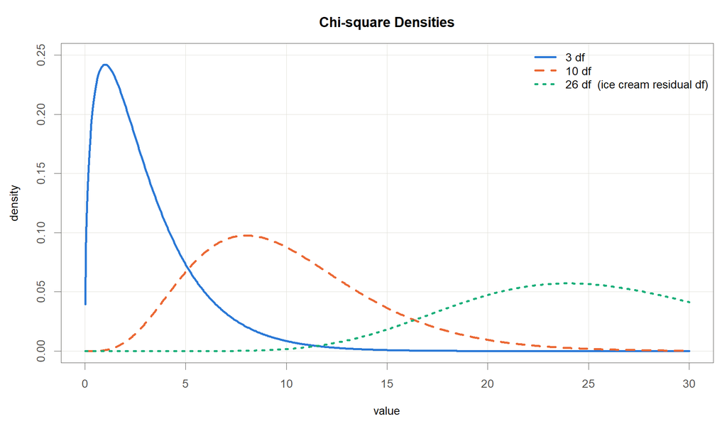

Chi-square densities for 3, 10, and 26 degrees of freedom

서로 독립인 표준정규 확률변수 $Z_1,\dots,Z_\nu$ 의 제곱을 모두 더하면
$$W=\sum_{i=1}^{\nu}Z_i^{2}$$
은 자유도 $\nu$ 의 **카이제곱분포** $\chi^2(\nu)$ 를 따른다.

- 제곱의 합이므로 항상 0 이상
- 오른쪽 꼬리가 긴 비대칭 분포
- $E(W)=\nu$, $\operatorname{Var}(W)=2\nu$
- $\nu$ 가 커지면 점차 대칭에 가까워짐

**회귀에서의 쓰임**: **흩어진 정도를 재는 양**의 분포. 잔차제곱합을 오차분산으로 나누면

$$\frac{\mathrm{SSE}}{\sigma^2}\sim\chi^2(n-p-1)$$

아이스크림 완전모형은 $\chi^2(26)$. 다음 두 분포가 모두 여기서 만들어짐

## t분포

### 정의

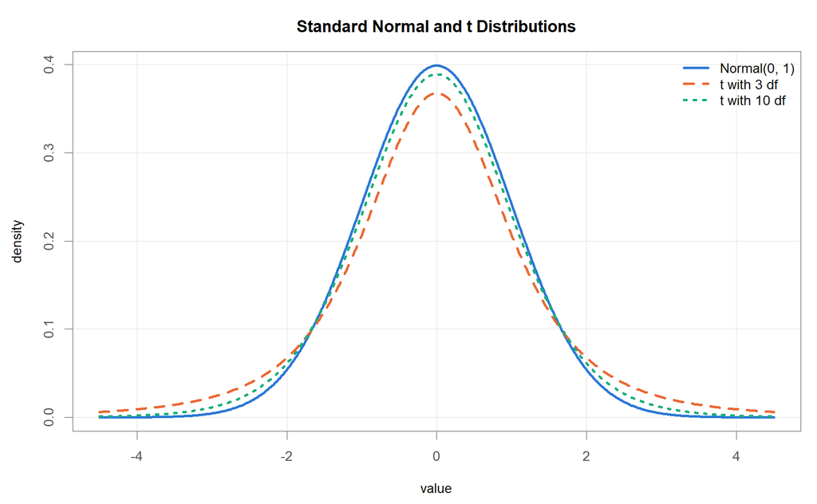

Standard normal and t distributions with 3 and 10 degrees of freedom

$\sigma$를 모른 채 표본표준편차 $s$로 대신하면
$$T=\frac{\bar X-\mu}{s/\sqrt{n}}$$
는 자유도 $n-1$의 **t분포**를 따른다.

- 정규분포보다 봉우리가 낮고 꼬리가 두꺼움
- $\sigma$ 를 추정하는 불확실성이 더해졌기 때문
- 자유도가 커지면 정규분포에 가까워짐
- **자유도** = 분산을 추정하는 데 쓸 수 있는 독립인 정보의 개수
- 자유도가 클수록 $s$가 $\sigma$에 가까워지므로 t분포는 $N(0,1)$에 수렴
- 양측 2.5% 임계값: 자유도 3에서 3.182, 자유도 10에서 2.228, 자유도 28에서 2.048, 정규분포는 1.960

**회귀에서의 쓰임**: 계수 검정에 자유도 $n-(p+1)$의 t분포. 아이스크림 자료의 단순회귀는 $30-2=28$

## F분포

### 정의

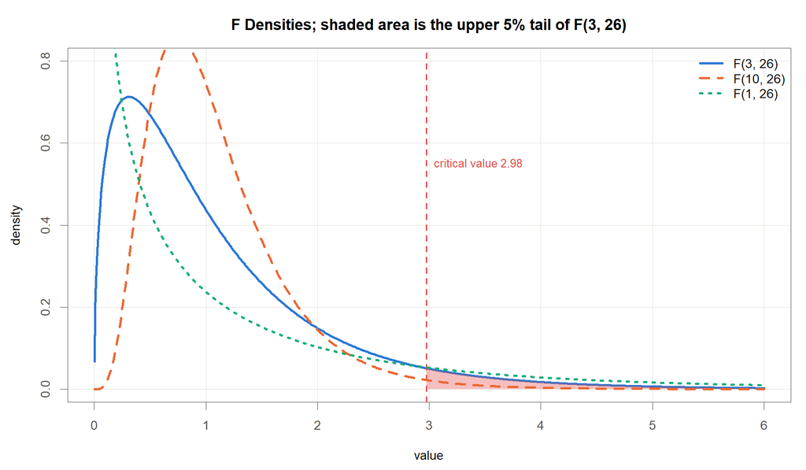

F densities; the shaded area is the upper 5 percent tail of F(3, 26)

서로 독립인 두 카이제곱 $W_1\sim\chi^2(\nu_1)$, $W_2\sim\chi^2(\nu_2)$ 를 각자의 자유도로 나눈 뒤 비를 취하면
$$F=\frac{W_1/\nu_1}{W_2/\nu_2}$$
은 자유도 $(\nu_1,\nu_2)$ 의 **F분포** 를 따른다.

- 두 분산의 비이므로 항상 0 이상
- 분자 쪽이 클수록 $F$ 가 커지므로 검정은 **오른쪽 꼬리만** 봄
- $\nu_1=1$ 이면 $F(1,\nu_2)=\{t(\nu_2)\}^2$

**회귀에서의 쓰임**: **두 분산 추정값의 비**. 모형이 설명한 몫과 남은 몫을 각자의 자유도로 나누어 견줌

$$F=\frac{\mathrm{SSR}/p}{\mathrm{SSE}/(n-p-1)}\sim F(p,\;n-p-1)$$

아이스크림 완전모형은 $F(3,26)$ 이고, 유의수준 5%의 기각역은 $F>2.98$

## 점추정: 추정량과 추정값

### 규칙과 숫자의 구분

- **모수** $\theta$: 모집단이 가진, 알 수 없는 상수
- **추정량** $\hat\theta$: 표본의 함수로 정의된 규칙이며 그 자체가 **확률변수**
- **추정값**: 특정 표본에 그 규칙을 적용해 실제로 나온 **숫자**.

Common point estimators. The estimator is the rule; the number it produces from one particular sample is the estimate

| Parameter $\theta$ | Estimator $\hat\theta$ | Name |
| --- | --- | --- |
| $\mu$ | $\bar X=\dfrac{1}{n}\sum_{i=1}^{n} X_i$ | Sample mean |
| $\sigma^2$ | $S^2=\dfrac{1}{n-1}\sum_{i=1}^{n}(X_i-\bar X)^2$ | Sample variance |
| $p$ | $\hat p=X/n$ | Sample proportion |

**표집오차**(sampling error) $=\hat\theta-\theta$. 표본이 바뀌면 이 값도 바뀌므로, 오차 하나가 아니라 **오차의 분포**를 봐야 함

- 같은 추정량이라도 **표본이 다르면 추정값이 다름**. 따라서 추정량의 좋고 나쁨은 한 번의 값이 아니라 **표집분포**로 판단
- **회귀에서의 쓰임**: $\hat\beta_0,\hat\beta_1$ 이 추정량이고, 자료 한 벌에서 계산된 $0.207$ 과 $0.00311$ 이 추정값

## 좋은 추정량: 편의와 변동성

### 과녁에 비유하면

$$\operatorname{MSE}(\hat\theta)=E\!\left[(\hat\theta-\theta)^2\right]
=\underbrace{\left[E(\hat\theta)-\theta\right]^2}_{\text{편의}^2\;\text{(bias)}}
+\underbrace{\operatorname{Var}(\hat\theta)}_{\text{변동성 (variance)}}$$

[figure not shown]

Reused from the earlier UST lecture note, 07-sampling-distribution

- **불편성**(unbiasedness) $E(\hat\theta)=\theta$: 반복하면 평균이 정확히 과녁 중심. 가로로 ① $\leftrightarrow$ ② 를 비교
- **변동성** $\operatorname{Var}(\hat\theta)$: 작을수록 탄착군이 조밀. 세로로 ① $\leftrightarrow$ ③ 을 비교
- $\sqrt{\operatorname{Var}(\hat\theta)}$ 가 **표준오차**
- 두 잣대 사이에는 **맞바꿈**이 있어 편의를 허용하면 변동성이 줄기도 함

**회귀에서의 쓰임**: 최소제곱 추정량 $\hat\beta_0,\hat\beta_1$ 이 ①에 해당한다는 주장이 3장의 **Gauss-Markov 정리**(불편이면서 그중 분산이 가장 작음)

## 신뢰구간

### 정의

**95% 신뢰구간**: 같은 절차로 표본 추출과 구간 계산을 반복했을 때, 만들어진 구간들 가운데 약 95%가 참값을 포함하도록 설계된 구간.

$$\hat\theta \pm t_{0.975,\;\nu}\times \operatorname{SE}(\hat\theta)$$

**기호**

- $\hat\theta$: 관심 모수의 추정값, $\operatorname{SE}(\hat\theta)$: 그 표준오차
- $t_{0.975,\nu}$: 자유도 $\nu$ 인 t분포의 상위 2.5% 지점. 자유도 28이면 2.048

**주의**

- 확률은 **구간**에 붙지 참값에 붙지 않음. 참값은 고정된 미지의 상수이며 구간이 표본마다 움직임
- “이 구간 안에 참값이 있을 확률이 95%”는 잘못된 서술
- 구간이 좁으면 정밀한 추정, 넓으면 정보가 부족한 추정

## 가설검정의 논리

### 정의

**귀무가설** $H_0$: 반증되기 전까지 참이라고 두는 기본 가정. 보통 “효과가 없다”, “차이가 없다” 쪽에 놓는다.

**대립가설** $H_1$: 자료로 입증하고자 하는 주장. 보통 “효과가 있다” 쪽이다.

### 절차

1. $H_0$와 $H_1$을 자료를 보기 전에 확정
2. 자료에서 검정통계량을 계산(예: $T=(\bar X-\mu_0)/(s/\sqrt{n})$)
3. $H_0$가 참일 때 그 통계량이 따르는 분포를 확인(예: 자유도 $n-1$의 t분포)
4. 관측된 통계량이 그 분포에서 얼마나 드문 값인지를 측정

검정의 결론은 $H_0$의 **기각** 또는 **기각하지 못함** 두 가지뿐. “$H_0$를 채택한다”는 표현은 쓰지 않음

**회귀에서의 쓰임**: 각 설명변수마다 $H_0:\beta_j=0$(그 변수의 기여가 없음) 대 $H_1:\beta_j\neq 0$의 검정

## p-value: 정의

### 꼬리 넓이

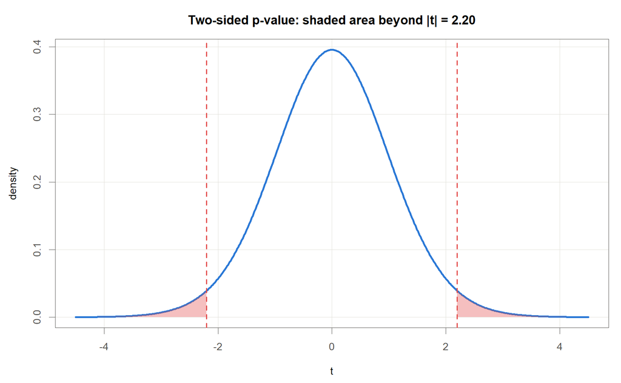

Two-sided p-value as the shaded tail area beyond |t| = 2.20, t distribution with 28 df

**p-value**: 귀무가설이 참이라고 가정할 때, 실제로 관측된 것만큼 또는 그보다 더 극단적인 결과가 나올 확률.

$$p=P\left(|T|\ge 2.20 \mid H_0\right)=0.0362$$

**기호**

- $T$: 자유도 28의 t분포를 따르는 검정통계량
- 계산은 `2 * pt(-2.20, 28) = 0.0362`

p가 작다 = 관측된 자료가 $H_0$ 아래에서 보기 드문 결과. 이때 $H_0$를 기각. 관례적 기준 $\alpha=0.05$는 학문 공동체의 약속일 뿐 자연법칙이 아님

앞서 본 95% 신뢰구간이 0을 포함하지 않는 것과 양측 검정의 $p<0.05$는 동일한 판정

**회귀에서의 쓰임**: 계수표의 p-value 열이 각 계수에 대한 이 확률

## p-value: 해석의 함정

### 네 가지 오독

1. **p는 귀무가설이 참일 확률이 아님**: $H_0$가 참이라는 조건을 붙이고 계산한 자료 쪽의 확률
   - 조건과 결론을 맞바꾸어 읽으면 안 됨
2. **p가 크다고 효과 없음이 증명되지는 않음**: 표본이 작거나 측정오차가 크면 실재하는 효과도 드러나지 않음
   - 증거 없음 $\neq$ 없음의 증거
3. **통계적 유의성 $\neq$ 실질적 중요성:** $n$이 매우 크면 실무적으로 무시할 만한 차이도 유의해짐
   - 효과의 크기를 함께 보고
4. **p = 0.049와 p = 0.051 사이에 질적 차이 없음**:
   - $p$는 0에서 1까지 **연속으로** 변하는 값이고, 0.05는 관습적인 **기준**
   - 유의/비유의로 자르지 말고 p 값을 그대로 보고

따라서 p-value는 추정값의 크기, 표준오차, 신뢰구간과 **함께** 보고할 것

American Statistical Association (2016), *Statement on Statistical Significance and P-Values*, The American Statistician 70(2), 129-133.

## 이 장의 정리

### Preliminary Knowledge

- 행렬 표기: $n$개의 식을 $\mathbf{y}=\mathbf{X}\boldsymbol{\beta}+\boldsymbol{\varepsilon}$ 한 줄로 압축. $\mathbf{X}$의 1열은 절편의 자리
- 새로 배운 연산: 전치 $\mathbf{X}^\top$, 행렬식 $\det$, 계수 $\operatorname{rank}$, 역행렬 $\mathbf{A}^{-1}$, 내적, 대각합 $\operatorname{tr}$, 벡터 미분
- $\det(\mathbf{X}^\top\mathbf{X})\neq 0$ ⟺ $\mathbf{X}$ 가 완전계수 ⟺ $\hat{\boldsymbol{\beta}}$ 가 하나로 정해짐
- 벡터 미분 두 공식으로 $S(\boldsymbol{\beta})$ 를 미분하면 정규방정식 $\mathbf{X}^\top\mathbf{X}\hat{\boldsymbol{\beta}}=\mathbf{X}^\top\mathbf{y}$
- 직교 $\mathbf{X}^\top\mathbf{e}=\mathbf{0}$ 은 제곱합 분해의 근거, 멱등행렬의 대각합은 자유도
- 최소제곱추정량 $\hat{\boldsymbol{\beta}}=(\mathbf{X}^\top\mathbf{X})^{-1}\mathbf{X}^\top\mathbf{y}$. 이후 모든 장이 이 한 줄의 특수한 경우
- 정규분포 $N(\mu,\sigma^2)$, 68-95-99.7 규칙. 회귀에서는 오차 $\varepsilon_i$ 의 가정
- 표집분포와 표준오차 $\sigma/\sqrt{n}$. 회귀에서는 계수표의 표준오차 열
- 정규분포에서 만들어지는 세 분포: $\chi^2$(제곱합), $t$(평균의 검정), $F$(두 분산의 비)
- t분포(자유도 $n-(p+1)$)로 계수 검정, F분포 $F(p,\,n-p-1)$ 로 모형 전체 검정
- 신뢰구간과 p-value. 회귀에서는 구간추정과 계수 검정

## 참고문헌

### 이 장에서 인용한 문헌

- Kutner, M. H., Nachtsheim, C. J., Neter, J., & Li, W. (2005). *Applied Linear Statistical Models*, 5th ed. McGraw-Hill. (행렬 표기)
- American Statistical Association (2016). Statement on statistical significance and p-values. *The American Statistician*, 70(2), 129-133.

### 교과서

- Kutner, M. H., Nachtsheim, C. J., Neter, J., & Li, W. (2005). *Applied Linear Statistical Models*, 5th ed. McGraw-Hill.
- Faraway, J. J. (2015). *Linear Models with R*, 2nd ed. CRC Press.